# Practical Machine Learning Assignment

Niraj Sinha

July 10, 2016

### Practical Machine Learning Assignment

# Background

Using devices such as Jawbone Up, Nike FuelBand, and Fitbit it is now possible to collect a large amount of data about personal activity relatively inexpensively. These type of devices are part of the quantified self movement - a group of enthusiasts who take measurements about themselves regularly to improve their health, to find patterns in their behavior, or because they are tech geeks. One thing that people regularly do is quantify how much of a particular activity they do, but they rarely quantify how well they do it. In this project, your goal will be to use data from accelerometers on the belt, forearm, arm, and dumbell of 6 participants. They were asked to perform barbell lifts correctly and incorrectly in 5 different ways.

# Data

The training data for this project are available here: https://d396qusza40orc.cloudfront.net/predmachlearn/pml-training.csv

The test data are available here: https://d396qusza40orc.cloudfront.net/predmachlearn/pml-testing.csv

The data for this project come from this source: http://groupware.les.inf.puc-rio.br/har.

# Goal

The goal of the project is to predict the manner in which the participants did the exercise.

# Data Intake & Transformation

First, we will upload the appropriate packages and set seed for reproducability:

```r
library(AppliedPredictiveModeling)
library(caret)
library(rattle)
library(rpart.plot)
library(randomForest)

set.seed(99999)
```

Next we import the data:

```r
trainDataUrl <- "http://d396qusza40orc.cloudfront.net/predmachlearn/pml-training.csv"
testDataUrl <- "http://d396qusza40orc.cloudfront.net/predmachlearn/pml-testing.csv"

if(!exists("trainData")){
    trainData <- read.csv(url(trainDataUrl), na.strings=c("NA","#DIV/0!",""),header=TRUE)
}
if(!exists("testData")){
    testData <- read.csv(url(testDataUrl), na.strings=c("NA","#DIV/0!",""),header=TRUE)
}
```

```r
# Partitioning the Training Data into two:
inTrain <- createDataPartition(trainData$classe, p=0.6, list=FALSE)
trainPart <- trainData[inTrain, ]
testPart <- trainData[-inTrain, ]
dim(trainPart)
```

```
## [1] 11776   160
```

```r
dim(testPart)
```

```
## [1] 7846  160
```

```r
# Remove variables from Taining Data that have near Zero Variance
NZV <- nearZeroVar(trainPart, saveMetrics=TRUE)
trainPart <- trainPart[,NZV$nzv==FALSE]

# Remove 1st column of training data
trainPart <- trainPart[c(-1)]

# Remove variables with more than 70% missing values
trainMod <- trainPart

for(i in 1:length(trainPart)) {
    if( sum( is.na( trainPart[, i] ) ) /nrow(trainPart) >= .7) {
        for(j in 1:length(trainMod)) {
            if( identical(names(trainPart)[i],names(trainMod)[j]))  {
                trainMod <- trainMod[ , -j]
            }
        }
    }
}
trainPart <- trainMod
rm(trainMod)


# testPart should have only variables that exist in trainPart
testPart <- testPart[colnames(trainPart)]

# Also, testData should only have variables that exist in trainPart MINUS 'classe'
testData <- testData[colnames(trainPart[, 1:length(trainPart)-1])]

# Coerce the data into the same type between trainPart and testData
for (i in 1:length(testData) ) {
    for(j in 1:length(trainPart)) {
        if( length( grep(names(trainPart[i]), names(testData)[j]) ) == 1)  {
            class(testData[j]) <- class(trainPart[i])
        }
    }
}

# To get the same class between testing and myTraining
testData <- rbind(trainPart[2, -58] , testData)
testData <- testData[-1,]
```

# ANALYSIS

#### Prediction with Decision Trees

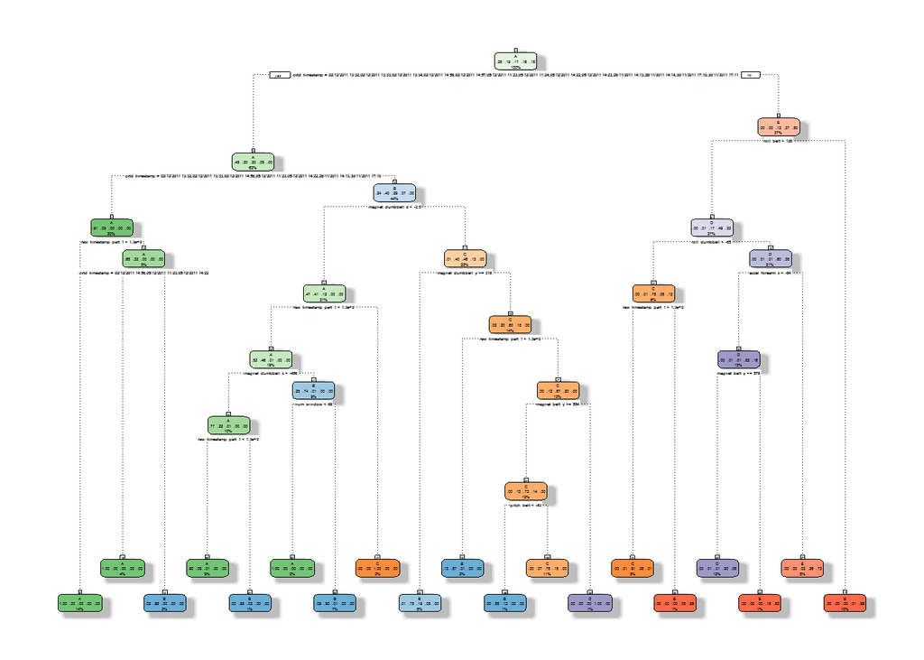

```r
set.seed(99999)
modFitDT <- rpart(classe ~ ., data=trainPart, method="class")
fancyRpartPlot(modFitDT, sub="")
```

```r
predictions <- predict(modFitDT, testPart, type = "class")
cm <- confusionMatrix(predictions, testPart$classe)
print(cm, digits=4)
```

```
## Confusion Matrix and Statistics
##
##           Reference
## Prediction    A    B    C    D    E
##          A 2148   61   10    4    0
##          B   81 1405  143   19    0
##          C    3   44 1190  167    3
##          D    0    8   14  881   88
##          E    0    0   11  215 1351
##
## Overall Statistics
##
##                Accuracy : 0.889
##                  95% CI : (0.8818, 0.8959)
##     No Information Rate : 0.2845
##     P-Value [Acc > NIR] : < 2.2e-16
##
##                   Kappa : 0.8595
##  Mcnemar's Test P-Value : NA
##
## Statistics by Class:
##
##                      Class: A Class: B Class: C Class: D Class: E
## Sensitivity            0.9624   0.9256   0.8699   0.6851   0.9369
## Specificity            0.9866   0.9616   0.9665   0.9832   0.9647
## Pos Pred Value         0.9663   0.8525   0.8458   0.8890   0.8567
## Neg Pred Value         0.9851   0.9818   0.9724   0.9409   0.9855
## Prevalence             0.2845   0.1935   0.1744   0.1639   0.1838
## Detection Rate         0.2738   0.1791   0.1517   0.1123   0.1722
## Detection Prevalence   0.2833   0.2100   0.1793   0.1263   0.2010
## Balanced Accuracy      0.9745   0.9436   0.9182   0.8342   0.9508
```

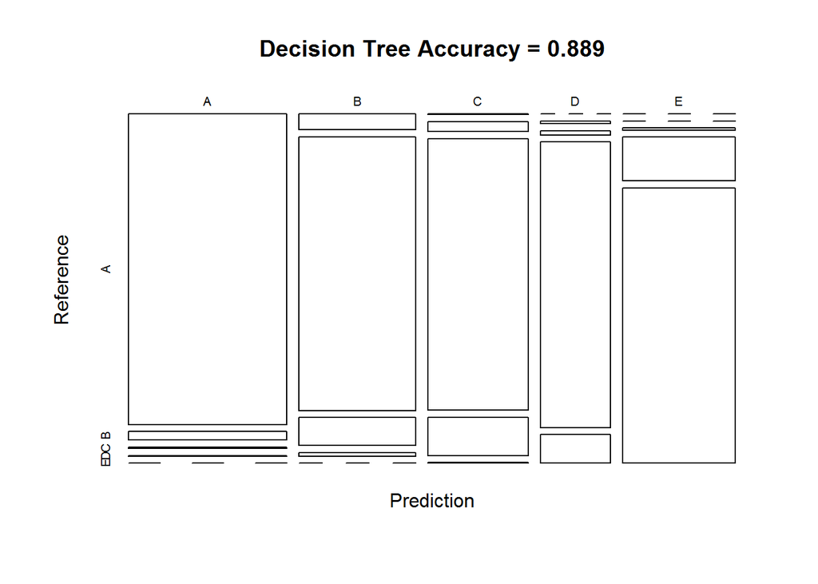

```r
plot(cm$table, col = cm$byClass, main = paste("Decision Tree Accuracy =", round(cm$overall['Accuracy'], 4)))
```

#### Prediction with Random Forest

```r
set.seed(99999)
modFitRF <- randomForest(classe ~ ., data=trainPart)
predictions <- predict(modFitRF, testPart, type = "class")
cm <- confusionMatrix(predictions, testPart$classe)
print(cm, digits=4)
```

```
## Confusion Matrix and Statistics
##
##           Reference
## Prediction    A    B    C    D    E
##          A 2231    1    0    0    0
##          B    1 1517    1    0    0
##          C    0    0 1367    3    0
##          D    0    0    0 1282    0
##          E    0    0    0    1 1442
##
## Overall Statistics
##
##                Accuracy : 0.9991
##                  95% CI : (0.9982, 0.9996)
##     No Information Rate : 0.2845
##     P-Value [Acc > NIR] : < 2.2e-16
##
##                   Kappa : 0.9989
##  Mcnemar's Test P-Value : NA
##
## Statistics by Class:
##
##                      Class: A Class: B Class: C Class: D Class: E
## Sensitivity            0.9996   0.9993   0.9993   0.9969   1.0000
## Specificity            0.9998   0.9997   0.9995   1.0000   0.9998
## Pos Pred Value         0.9996   0.9987   0.9978   1.0000   0.9993
## Neg Pred Value         0.9998   0.9998   0.9998   0.9994   1.0000
## Prevalence             0.2845   0.1935   0.1744   0.1639   0.1838
## Detection Rate         0.2843   0.1933   0.1742   0.1634   0.1838
## Detection Prevalence   0.2845   0.1936   0.1746   0.1634   0.1839
## Balanced Accuracy      0.9997   0.9995   0.9994   0.9984   0.9999
```

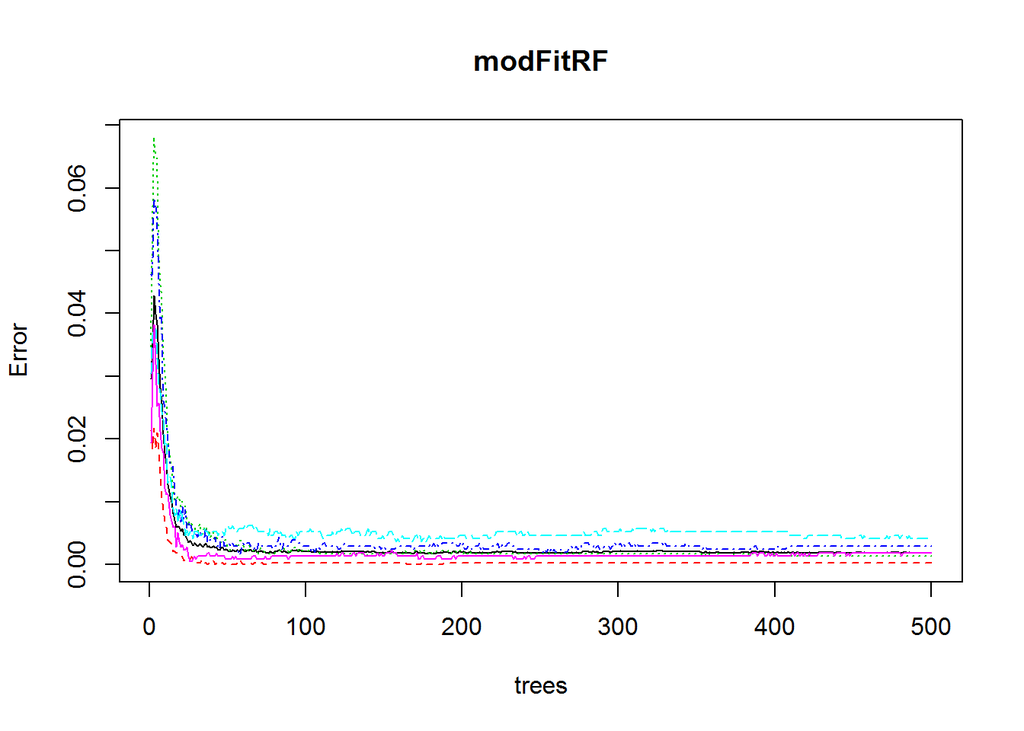

```r
plot(modFitRF)
```

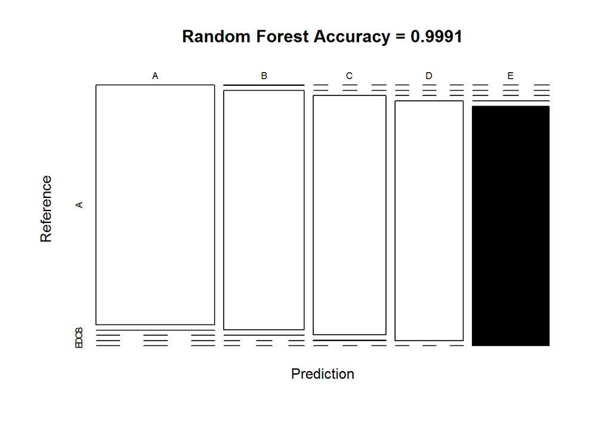

```r
plot(cm$table, col = cm$byClass, main = paste("Random Forest Accuracy =", round(cm$overall['Accuracy'], 4)))
```

#### Prediction with Generalized Boosted Regression

```r
set.seed(99999)
fitControl <- trainControl(method = "repeatedcv",number = 5,repeats = 1)
modFitGBM <- train(classe ~ ., data=trainPart, method = "gbm",trControl = fitControl, verbose = FALSE)

predictions <- predict(modFitGBM, newdata=testPart)
cm <- confusionMatrix(predictions, testPart$classe)
print(cm, digits=4)
```

```
## Confusion Matrix and Statistics
##
##           Reference
## Prediction    A    B    C    D    E
##          A 2231    2    0    0    0
##          B    1 1512    1    0    0
##          C    0    3 1355    4    0
##          D    0    1   12 1279    1
##          E    0    0    0    3 1441
##
## Overall Statistics
##
##                Accuracy : 0.9964
##                  95% CI : (0.9948, 0.9976)
##     No Information Rate : 0.2845
##     P-Value [Acc > NIR] : < 2.2e-16
##
##                   Kappa : 0.9955
##  Mcnemar's Test P-Value : NA
##
## Statistics by Class:
##
##                      Class: A Class: B Class: C Class: D Class: E
## Sensitivity            0.9996   0.9960   0.9905   0.9946   0.9993
## Specificity            0.9996   0.9997   0.9989   0.9979   0.9995
## Pos Pred Value         0.9991   0.9987   0.9949   0.9892   0.9979
## Neg Pred Value         0.9998   0.9991   0.9980   0.9989   0.9998
## Prevalence             0.2845   0.1935   0.1744   0.1639   0.1838
## Detection Rate         0.2843   0.1927   0.1727   0.1630   0.1837
## Detection Prevalence   0.2846   0.1930   0.1736   0.1648   0.1840
## Balanced Accuracy      0.9996   0.9979   0.9947   0.9962   0.9994
```

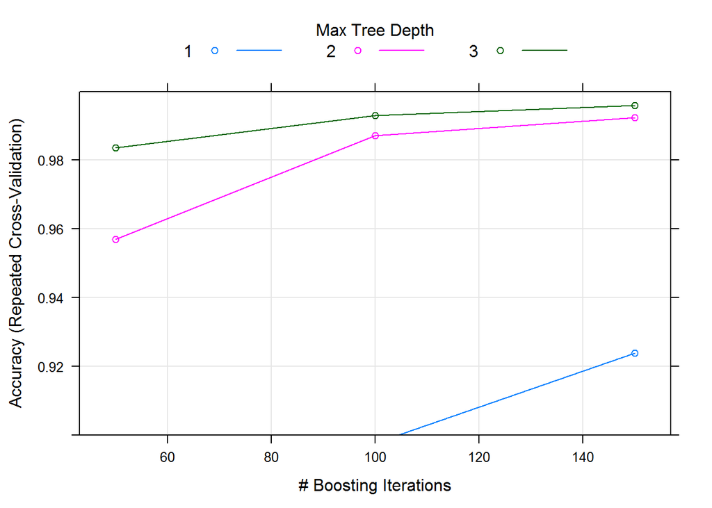

```r
plot(modFitGBM, ylim=c(0.9, 1))
```

# Conclusion

The expected out-of-sample error is 100-99.91 = 0.09%.

#### Predictions with Test Data

```r
predictions <- predict(modFitRF, testData, type = "class")
predictions
```

[output not shown]